# The Impact of Weather Events on Population Health and Economics

Reproducible Research Course Project 2 Elizabeth Harris  
July 1, 2017

## Synopsis

Weather events have both an economic and population health impact on communities across the county. The US National Oceanic and Atmospheric Administration’s (NOAA) storm database allows us to analyze the impact of these events. The data base tracks characteristics of these events including, where and when they occur, estimates of fatalities, injuries, and damage to property and crops. Using this data I analyzed the economic and health impact of different event types. I am working to address the following questions:

- Across the US, which types of weather events are most harmful with respect to population health?
- Across the US, which types of events have the greatest economic consequences?

### Load, Unzip, & Read Data

To begin the analysis, I activated the R packages I would need, downloaded, unzipped, and read the data into R. I have hidden the results of the code because it makes the document unnecessarily long.

```r
library(R.utils)
library(dplyr)
```

```r
library(ggplot2)
zip <- "https://d396qusza40orc.cloudfront.net/repdata%2Fdata%2FStormData.csv.bz2"
download.file(zip, "StormData.csv.bz2")
if (!file.exists("StormData.csv")) {
       bunzip2("StormData.csv.bz2", "StormData.csv", remove = FALSE)
       }
stormdata <- read.csv("StormData.csv")
```

## Process Data

### 1. Review Data

I began by reviewing the data by looking at the first and last five rows of data in the data frame.

```r
head(stormdata, 5)
```

```
##   STATE__           BGN_DATE BGN_TIME TIME_ZONE COUNTY COUNTYNAME STATE
## 1       1  4/18/1950 0:00:00     0130       CST     97     MOBILE    AL
## 2       1  4/18/1950 0:00:00     0145       CST      3    BALDWIN    AL
## 3       1  2/20/1951 0:00:00     1600       CST     57    FAYETTE    AL
## 4       1   6/8/1951 0:00:00     0900       CST     89    MADISON    AL
## 5       1 11/15/1951 0:00:00     1500       CST     43    CULLMAN    AL
##    EVTYPE BGN_RANGE BGN_AZI BGN_LOCATI END_DATE END_TIME COUNTY_END
## 1 TORNADO         0                                               0
## 2 TORNADO         0                                               0
## 3 TORNADO         0                                               0
## 4 TORNADO         0                                               0
## 5 TORNADO         0                                               0
##   COUNTYENDN END_RANGE END_AZI END_LOCATI LENGTH WIDTH F MAG FATALITIES
## 1         NA         0                      14.0   100 3   0          0
## 2         NA         0                       2.0   150 2   0          0
## 3         NA         0                       0.1   123 2   0          0
## 4         NA         0                       0.0   100 2   0          0
## 5         NA         0                       0.0   150 2   0          0
##   INJURIES PROPDMG PROPDMGEXP CROPDMG CROPDMGEXP WFO STATEOFFIC ZONENAMES
## 1       15    25.0          K       0
## 2        0     2.5          K       0
## 3        2    25.0          K       0
## 4        2     2.5          K       0
## 5        2     2.5          K       0
##   LATITUDE LONGITUDE LATITUDE_E LONGITUDE_ REMARKS REFNUM
## 1     3040      8812       3051       8806              1
## 2     3042      8755          0          0              2
## 3     3340      8742          0          0              3
## 4     3458      8626          0          0              4
## 5     3412      8642          0          0              5
```

```r
tail(stormdata, 5)
```

```
##        STATE__           BGN_DATE    BGN_TIME TIME_ZONE COUNTY
## 902293      56 11/30/2011 0:00:00 10:30:00 PM       MST      7
## 902294      30 11/10/2011 0:00:00 02:48:00 PM       MST      9
## 902295       2  11/8/2011 0:00:00 02:58:00 PM       AKS    213
## 902296       2  11/9/2011 0:00:00 10:21:00 AM       AKS    202
## 902297       1 11/28/2011 0:00:00 08:00:00 PM       CST      6
##          COUNTYNAME STATE     EVTYPE BGN_RANGE BGN_AZI BGN_LOCATI
## 902293 WYZ007 - 017    WY  HIGH WIND         0
## 902294 MTZ009 - 010    MT  HIGH WIND         0
## 902295       AKZ213    AK  HIGH WIND         0
## 902296       AKZ202    AK   BLIZZARD         0
## 902297       ALZ006    AL HEAVY SNOW         0
##                  END_DATE    END_TIME COUNTY_END COUNTYENDN END_RANGE
## 902293 11/30/2011 0:00:00 10:30:00 PM          0         NA         0
## 902294 11/10/2011 0:00:00 02:48:00 PM          0         NA         0
```

[output cut: 39 more lines]

### 2. Convert names from upper case to lower case

The data review showed that I needed to convert the variable names from upper to lower case, which makes future code much easier. Based on the type of analysis that I will be doing I am also able to see that I can trim some variables from the data frame. After trimming the data frame, I checked to see if there was any missing data in the data frame. Since there was none, I did not need to remove or impute the data.

```r
names(stormdata) <- tolower(names(stormdata))
stormdata2 <- select(tbl_df(stormdata), evtype, fatalities:cropdmgexp)
sum(is.na(stormdata2))
```

```
## [1] 0
```

After reviewing and transforming the data, I was ready to process the specific variables I needed in order to effectively address my questions

### 3. Summarize Population Health Info

In order to address the impact of weather events on population health, I first needed to look a that the two health variables in the data set - fatalities and injuries.

#### 3.1 Calculate fatalaties and injuries

```r
storm_health <- stormdata2 %>% select(evtype, fatalities, injuries)
storm_fatalities <- stormdata2 %>% select(evtype, fatalities) %>% group_by(evtype) %>%
       summarise(total_fatalities = sum(fatalities)) %>% arrange(-total_fatalities)
storm_injuries <- stormdata2 %>% select(evtype, injuries) %>% group_by(evtype) %>%
       summarise(total_injuries = sum(injuries)) %>% arrange(-total_injuries)
```

#### 3.2 Combine injuries and fatalaties

After looking at fatalities and injuries separately, I chose to combine the two variables into a single variable that showed the total number of casualties. A casualty is a person killed or injured in a war or accident, so I used the mutate() object from the dplyr package to add a new variable called total_health to the data frame. Finally, I summarized the storm health data by the event type and number of casualties.

```r
storm_health <- mutate(storm_health,total_health = fatalities + injuries)
storm_health_total <- storm_health %>% group_by(evtype) %>% summarize(total_health_evtype
       = sum(total_health))%>% arrange(-total_health_evtype)
```

### 4. Summarize Economic Info

The processing of economic impact data was more complex because it required more data transformation than the health data. The propdmg and cropdmg variable provide the scale, while the propdmgexp and cropdmgexp variables indicate the parameters. Based on the [documentation](https://d396qusza40orc.cloudfront.net/repdata%2Fpeer2_doc%2Fpd01016005curr.pdf) for the data set, the parameters can be defined as:

- H, h -> hundreds = x100
- K, K -> kilos = x1,000
- M, m -> millions = x1,000,000
- B,b -> billions = x1,000,000,000
- (+) -> x1
- (-) -> x0
- (?) -> x0
- blank -> x0

#### 4.1 Convert symbols to numbers

```r
storm_damage <- stormdata2 %>% select(evtype, propdmg,propdmgexp,cropdmg,cropdmgexp)
symbol <- sort(unique(as.character(storm_damage$propdmgexp)))
multiplier <- c(0,0,0,1,10,10,10,10,10,10,10,10,10,10^9,10^2,10^2,10^3,10^6,10^6)
convert_multiplier <- data.frame(symbol, multiplier)
storm_damage$prop_multiplier <- convert_multiplier$multiplier[match(storm_damage$propdmgexp,
       convert_multiplier$symbol)]
storm_damage$crop_multiplier <- convert_multiplier$multiplier[match(storm_damage$cropdmgexp,
       convert_multiplier$symbol)]
```

#### 4.2 Combine and Summarize Economic Impact

With the data transformed, I combined the crop damage and property damage variables into a single variable called storm_damage, again using the mutate() object from the dplyr package. Then I summarized the data based on the event type.

```r
storm_damage <- storm_damage %>% mutate(propdmg = propdmg*prop_multiplier) %>%
       mutate(cropdmg = cropdmg*crop_multiplier) %>% mutate(total_damage = propdmg+cropdmg)
storm_damage_total <- storm_damage %>% group_by(evtype) %>% summarize(total_damage_evtype
       = sum(total_damage))%>% arrange(-total_damage_evtype)
```

## Results

After processing the data, I was able to create graphics that help address to the two questions that began the report.

### 1. Population Health Impact

My original question was, “Across the US, which types of events are most harmful with respect to population health?” Based on the information contained in the graph below, the answer is tornadoes, which accounts for 96979 injuries and fatalities. This is far above excessive heat.

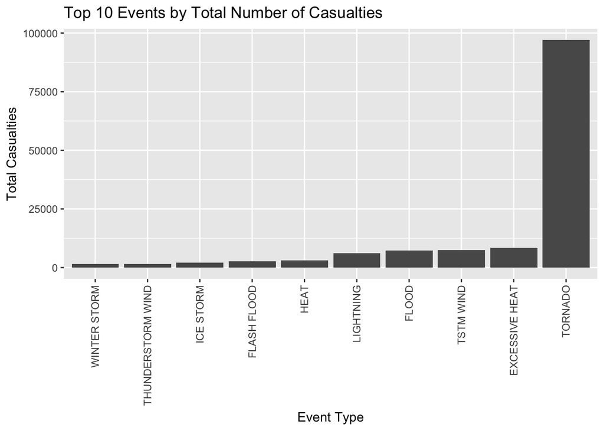

```r
ggplot(data = storm_health_total[1:10,], aes(x = reorder(evtype, total_health_evtype),
       y = total_health_evtype)) + geom_bar(stat = "identity") + theme(axis.text.x =
       element_text(angle=90, vjust=0.5, hjust=1)) +
       ggtitle("Top 10 Events by Total Number of Casualties") +
       labs(x = "Event Type", y = "Total Casualties")
```

### 2. Economic Impact

My original question was, “Across the US, which types of events have the greatest economic consequences?” Based on the information contained in the graph below, the answer is floods, which accounts for $150,319,678,250 in damage. This is far above hurricane/typhoon at number two.

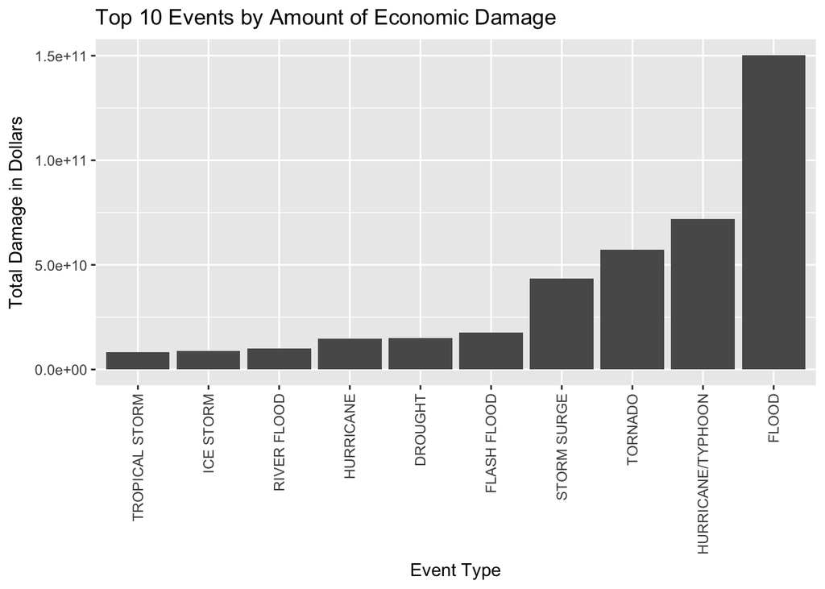

```r
ggplot(data = storm_damage_total[1:10,], aes(x = reorder(evtype, total_damage_evtype),
       y = total_damage_evtype)) + geom_bar(stat = "identity") + theme(axis.text.x =
       element_text(angle=90, vjust=0.5, hjust=1)) +
       ggtitle("Top 10 Events by Amount of Economic Damage") +
       labs(x = "Event Type", y = "Total Damage in Dollars")
```